# Yelp Final Project Rubric - Top 10 variables which determine a restaurant business having more than 3 stars rating.

author: Steven Lee date: 21/11/2015 transition: rotate

# A primary question of interest

Which are the 10 variables that determine a restaurant business having more than 3 stars rating?

Will there be any changes in the top 10 variables if we will to use some sentimental analysis on tip and reviews dataset to create a new normalised sentimental star rating as compared to Yelp’s star rating?

### Dataset required

- 1. Yelp Business data (dimension: 61184 x 109)
- 2. Yelp Tips data (dimension: 495107 x 5)
- 3. Yelp Reviews data (dimension: 1569264 x 9)

# 3Methodology

### Extraction + Merging

- Extraction of “Restaurant” Business data in the tagging.
- Merging “Restaurant” Business data with Tips & Review, using “inner-join” with “business id”" as key-variable

### Sentimental Analysis score

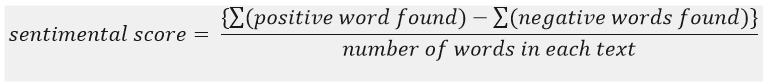

- Get the average sentimental_score by each Restaurant “business id”. - “inner-join” back the average sentimental_score to “Restaurant” Business data

# Data Exploration + Machine Learning

### Plot of yelp’s star rating vs Sentimental star rating

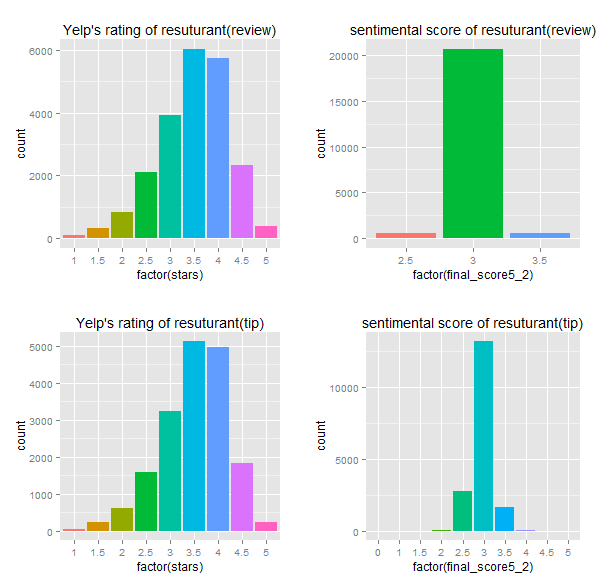

*** ### Machines learning - Target variable (yelp stars)= at least 3 stars - Target variable (sentimental stars) = at least 3 stars - Random forest implementation with 5 times cross-validation

# Results

- All 4 Models have good accuracy from 84% to 98%.
- Able to show the top 10 variables of each model (yelp and sentimental star).
- Amount the top 10, 7 variables appeared in all 4 (highlighted in yellow).
- Some are unqiue varibles which only appear once across the 4 models (in red font).

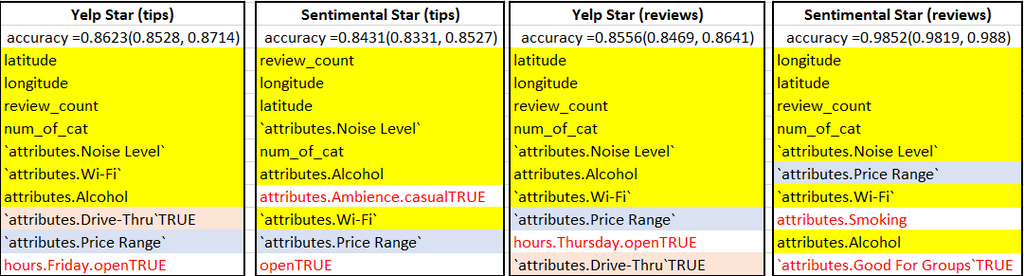